# US weather conditions affects economics and public health

Daniel Fernandez

## Loading packages and functions

```r
#download packages if needed
list.of.packages <- c("plyr","grid","ggplot2")
new.packages <- list.of.packages[!(list.of.packages %in% installed.packages()[,"Package"])]
if(length(new.packages)) install.packages(new.packages)

#load packages and functions
library("plyr")
library("grid")
library("ggplot2")
source("giveConsistencyEVTYPE.R")
source("convertEXP.R")
```

## Data loading

```r
#download and read data
#download.file('https://d396qusza40orc.cloudfront.net/repdata%2Fdata%2FStormData.csv.bz2', destfile='stormData.csv.bz2', method='curl')
```

## Data processing

The NOAA provides in its webpage a dataset that tracks characteristics of major storms and weather events in the United States, including when and where they occur, as well as estimates of any fatalities, injuries, and property damage since the 50s.

```r
storm.data <- read.csv('stormData.csv.bz2')
```

As this is a large data frame, it is interesting to work only with the data that contains some useful values. In this study, we want to check which weather conditions has caused economics or public health damages. Then we are interesting in the data for this variables that is bigger than 0:

```r
#I reduce our data frame to only the values that have some kind of interest for this study
sub.storm <- storm.data[storm.data$FATALITIES > 0 | storm.data$INJURIES >0 | storm.data$PROPDMG >0 | storm.data$CROPDMG > 0,]
```

We encounter a big problem when working with this dataset. The U.S. National Oceanic and Atmospheric Administration’s (NOAA) defines 48 different weather events, but we can find that the EVTYPE field of the dataset has more that 900 different events, this is unconsistent and makes really difficult the work as we need to group all these different events under 48.

I have decided to reduce my study to the last 15 years. That reduces considerable the number of event types defined in the dataset.

The steps followed to give some consistency to the events are: 1.Convert the information in the BGN_DATE to date 2.Create a data frame with the values that are bigger than 1999-01-01 in BGN_DATE 3.Use a function called giveConsistencyEVTYPE that groups all the events in EVTYPE in 49 events, the events defined by the NOAA and one more event called Others.

```r
#I convert the date
sub.storm$BGN_DATE <- as.Date(sub.storm$BGN_DATE, "%m/%d/%Y %H:%M:%S")

#EVTYPE is quite inconsistent, as it is very time consuming to reduce almost 1000 variables to the 48 that are defined by the National weather service in the documentation, I have decided to reduce my study to the last 15 years.
sub.storm2 <- sub.storm[sub.storm$BGN_DATE > "1999-01-01", ]

sub.storm2 <- giveConsistencyEVTYPE(sub.storm2)
```

After the events are consistent, we can go ahead and calculate the number of fatalities and injures that have occurred in the last 15 years to the weather conditions:

```r
#health data processing
fatalities.type <- ddply(sub.storm2, .(EVTYPE), summarize, steps = sum(FATALITIES, na.rm=TRUE))
colnames(fatalities.type)[2] <- c("Fatalities")
injuries.type <- ddply(sub.storm2, .(EVTYPE), summarize, steps = sum(INJURIES, na.rm=TRUE))
colnames(injuries.type)[2] <- c("Injuries")

health.data <- merge(fatalities.type, injuries.type, by="EVTYPE")
```

We can do the same and compute the loses that weather conditions have caused in properties and crop. But first of all, we need to do a new data manipulation, as some values in columns PROPDMGEXP and CROPDMGEXP are not defined as integers. We use the function convertEXP.R to modify these columns:

```r
#economics data processing
levels(sub.storm2$PROPDMGEXP)
```

```
##  [1] ""  "-" "?" "+" "0" "1" "2" "3" "4" "5" "6" "7" "8" "B" "h" "H" "K"
## [18] "m" "M"
```

```r
levels(sub.storm2$CROPDMGEXP)
```

```
## [1] ""  "?" "0" "2" "B" "k" "K" "m" "M"
```

```r
sub.storm2 <- convertEXP(sub.storm2)
```

Finally we can compute the loses for the last 15 years by event:

```r
sub.storm2$PROPDMGTOT <- sub.storm2$PROPDMG * 10^as.integer(sub.storm2$PROPDMGEXP)
sub.storm2$CROPDMGTOT <- sub.storm2$CROPDMG * 10^as.integer(sub.storm2$CROPDMGEXP)
propdmg.type <- ddply(sub.storm2, .(EVTYPE), summarize, steps = sum(PROPDMGTOT, na.rm=TRUE))
colnames(propdmg.type)[2] <- c("Propdmg")
cropdmg.type <- ddply(sub.storm2, .(EVTYPE), summarize, steps = sum(CROPDMGTOT, na.rm=TRUE))
colnames(cropdmg.type)[2] <- c("Cropdmg")

economics.data <- merge(propdmg.type, cropdmg.type, by="EVTYPE")
```

## Results

### The most harmful event with respect to population health

```r
#Results health
#get the 15 that are most harmful with respect to population health
top15.health.data <- arrange(health.data, desc(Injuries))[1:15, ]
print(top15.health.data[,c(1,3)])
```

```
##                 EVTYPE Injuries
## 1              Tornado    17041
## 2       Excessive Heat     6393
## 3    Thunderstorm Wind     3477
## 4            Lightning     3236
## 5             Wildfire     1326
## 6  Hurricane (Typhoon)     1295
## 7          Flash Flood     1093
## 8            High Wind      878
## 9         Winter Storm      670
## 10                Hail      629
## 11           Dense Fog      558
## 12      Winter Weather      555
## 13         Rip Current      414
## 14          Heavy Snow      375
## 15               Flood      363
```

```r
top15.health.data <- arrange(health.data, desc(Fatalities))[1:15, ]
print(top15.health.data[,c(1:2)])
```

```
##                 EVTYPE Fatalities
## 1       Excessive Heat       1746
## 2              Tornado       1287
## 3          Flash Flood        649
## 4            Lightning        512
## 5          Rip Current        485
## 6                Flood        297
## 7    Thunderstorm Wind        276
## 8      Cold/Wind Chill        220
## 9            Avalanche        205
## 10           High Wind        175
## 11           High Surf        139
## 12        Winter Storm        112
## 13         Strong Wind        101
## 14            Wildfire         86
## 15 Hurricane (Typhoon)         84
```

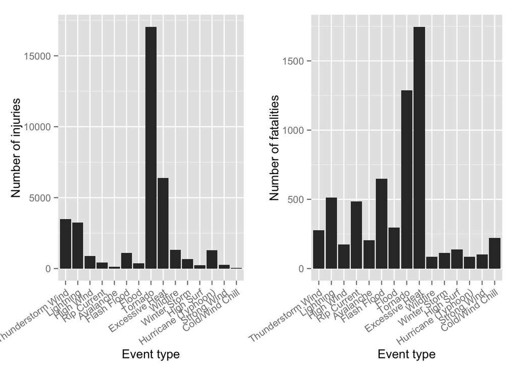

```r
#plot the 15 that are most harmful with respect to population health
plot1 <- ggplot(top15.health.data, aes(x = EVTYPE, y = Injuries))
plot1 <- plot1 + geom_bar(stat = "identity")
plot1 <- plot1 + xlab("Event type") + ylab("Number of injuries")
plot1 <- plot1 + theme(axis.text.x = element_text(angle = 35, hjust = 1))

plot2 <- ggplot(top15.health.data, aes(x = EVTYPE, y = Fatalities))
plot2 <- plot2 + geom_bar(stat = "identity")
plot2 <- plot2 + xlab("Event type") + ylab("Number of fatalities")
plot2 <- plot2 + theme(axis.text.x = element_text(angle = 35, hjust = 1))

vplayout <- function(x, y) viewport(layout.pos.row = x, layout.pos.col = y)

grid.newpage()
pushViewport(viewport(layout = grid.layout(1, 2)))
print(plot1, vp = vplayout(1, 1))
print(plot2, vp = vplayout(1, 2))
```

We can see in the results that excessive heat and tornados are the events that have caused more harmful in public health in the US for the last 15 years. Tornados are by far the event that has caused more injuries, but excessive heat has caused more fatalities.

### The weather events that had most impanct on economy for the last 15 years

```r
top15.economics.data <- arrange(economics.data, desc(Propdmg))[1:15, ]
print(top15.economics.data[,c(1:2)])
```

```
##                 EVTYPE   Propdmg
## 1                Flood 1.351e+11
## 2  Hurricane (Typhoon) 7.651e+10
## 3     Storm Surge/Tide 4.782e+10
## 4              Tornado 2.145e+10
## 5          Flash Flood 1.293e+10
## 6                 Hail 1.245e+10
## 7             Wildfire 7.255e+09
## 8       Tropical Storm 7.218e+09
## 9    Thunderstorm Wind 5.851e+09
## 10           High Wind 5.036e+09
## 11           Ice Storm 2.944e+09
## 12        Winter Storm 1.406e+09
## 13             Drought 8.476e+08
## 14           Lightning 6.305e+08
## 15          Heavy Rain 4.944e+08
```

```r
top15.economics.data <- arrange(economics.data, desc(Cropdmg))[1:15, ]
print(top15.economics.data[,c(1,3)])
```

```
##                     EVTYPE   Cropdmg
## 1                  Drought 1.047e+10
## 2      Hurricane (Typhoon) 4.436e+09
## 3                    Flood 4.289e+09
## 4                     Hail 1.980e+09
## 5              Flash Flood 1.210e+09
## 6             Frost/Freeze 1.148e+09
## 7        Thunderstorm Wind 7.411e+08
## 8                High Wind 5.037e+08
## 9           Excessive Heat 4.926e+08
## 10          Tropical Storm 4.522e+08
## 11              Heavy Rain 4.116e+08
## 12 Extreme Cold/Wind Chill 3.298e+08
## 13                Wildfire 3.062e+08
## 14                 Tornado 2.431e+08
## 15             Strong Wind 6.495e+07
```

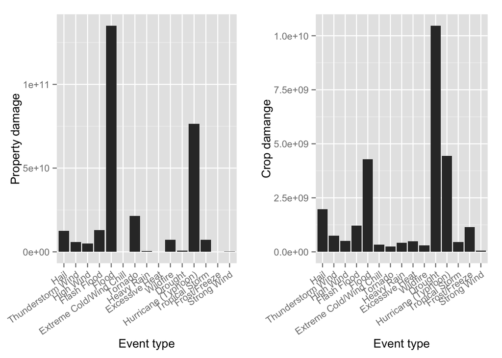

```r
plot1 <- ggplot(top15.economics.data, aes(x = EVTYPE, y = Propdmg))
plot1 <- plot1 + geom_bar(stat = "identity")
plot1 <- plot1 + xlab("Event type") + ylab("Property damage")
plot1 <- plot1 + theme(axis.text.x = element_text(angle = 35, hjust = 1))

plot2 <- ggplot(top15.economics.data, aes(x = EVTYPE, y = Cropdmg))
plot2 <- plot2 + geom_bar(stat = "identity")
plot2 <- plot2 + xlab("Event type") + ylab("Crop damange")
plot2 <- plot2 + theme(axis.text.x = element_text(angle = 35, hjust = 1))

vplayout <- function(x, y) viewport(layout.pos.row = x, layout.pos.col = y)

grid.newpage()
pushViewport(viewport(layout = grid.layout(1, 2)))
print(plot1, vp = vplayout(1, 1))
print(plot2, vp = vplayout(1, 2))
```

When we check the results in our study related to economics, we see that the weather event that has causes more property loses in the last 15 years is flood. On the other hand, when we talk about crop damange, we can see something that was probably expected. The biggest damanges are related to drought; event if hurricanes and floods also affect it.